# Прогнозирование заказов такси

Такси-компания собрала исторические данные о заказах такси в аэропортах. Чтобы привлекать больше водителей в период пиковой нагрузки, нужно спрогнозировать количество заказов такси на следующий час. Постройте модель для такого предсказания.

Задача: **Значение метрики *RMSE* на тестовой выборке должно быть не больше 48.**

**План работы**:

1. Загрузить данные и выполнить их ресемплирование по одному часу.
2. Проанализировать данные.
3. Обучить разные модели с различными гиперпараметрами. Сделать тестовую выборку размером 10% от исходных данных.
4. Проверить данные на тестовой выборке и сформулировать вывод.

Данные лежат в файле `taxi.csv`. Количество заказов находится в столбце `num_orders`.

# Импорт библиотек и объявление констант

```python
from IPython.core.display import display, HTML
display(HTML("<style>.container { width:75% !important; }</style>"))
```

```python
import warnings
warnings.simplefilter(action='ignore', category=Warning)

import time as tm

import numpy as np

!pip install pandas --upgrade -q
import pandas as pd

!pip install matplotlib --upgrade -q
import matplotlib.pyplot as plt

!pip install statsmodels --upgrade -q
from statsmodels.tsa.seasonal import seasonal_decompose
from statsmodels.tsa.stattools import adfuller

!pip install LightGBM -q
from lightgbm import LGBMRegressor

!pip install catboost -q
from catboost import CatBoostRegressor, cv

!pip install scikit-learn --upgrade -q
from sklearn.model_selection import train_test_split
from sklearn.metrics import mean_squared_error as mse
from sklearn.pipeline import Pipeline
from sklearn.compose import ColumnTransformer
from sklearn.preprocessing import StandardScaler, MinMaxScaler, RobustScaler
from sklearn.linear_model import LinearRegression
from sklearn.tree import DecisionTreeRegressor
from sklearn.svm import SVR
from sklearn.model_selection import GridSearchCV, RandomizedSearchCV, TimeSeriesSplit

alpha = 0.01
RANDOM_STATE = 17
test_size = 0.1
```

[output not shown]

# Функции для проекта

```python
def resampled_seasonal_plots():

    df_week, df_month, df_3days, df_1day = df.resample('2w').sum(), df.resample('1M').sum(), df.resample('3d').sum(), df.resample('1d').sum()

    decomposed_month = seasonal_decompose(df_month, period=1)
    decomposed_week = seasonal_decompose(df_week, period=1)
    decomposed_3days = seasonal_decompose(df_3days, period=1)
    decomposed_1day = seasonal_decompose(df_1day, period=1)

    comps = ['trend', 'seasonality', 'residuals']

    fig, ax = plt.subplots(1, 3, figsize=(25, 5))

    fig.suptitle('Month', fontsize=25)

    for i, j in zip([decomposed_month.trend, decomposed_month.seasonal, decomposed_month.resid], comps):

        i.plot(ax=ax[comps.index(j)])

        ax[comps.index(j)].set_title(j)
        ax[comps.index(j)].set_ylabel('orders')

    fig.tight_layout()
    plt.show()

    fig, ax = plt.subplots(1, 3, figsize=(25, 5))

    fig.suptitle('2 weeks', fontsize=25)

    for i, j in zip([decomposed_week.trend, decomposed_week.seasonal, decomposed_week.resid], comps):

        i.plot(ax=ax[comps.index(j)])

        ax[comps.index(j)].set_title(j)
        ax[comps.index(j)].set_ylabel('orders')

    fig.tight_layout()
    plt.show()

    fig, ax = plt.subplots(1, 3, figsize=(25, 5))

    fig.suptitle('3 days', fontsize=25)

    for i, j in zip([decomposed_3days.trend, decomposed_3days.seasonal, decomposed_3days.resid], comps):

        i.plot(ax=ax[comps.index(j)])

        ax[comps.index(j)].set_title(j)
        ax[comps.index(j)].set_ylabel('orders')

    fig.tight_layout()
    plt.show()

    fig, ax = plt.subplots(1, 3, figsize=(25, 5))

    fig.suptitle('1 day', fontsize=25)

    for i, j in zip([decomposed_1day.trend, decomposed_1day.seasonal, decomposed_1day.resid], comps):

        i.plot(ax=ax[comps.index(j)])

        ax[comps.index(j)].set_title(j)
        ax[comps.index(j)].set_ylabel('orders')

    fig.tight_layout()
    plt.show()
```

```python
def make_features(df, max_lag, rolling_mean_size):

    data = df.copy()

    data['month'] = df.index.month
    data['dayofweek'] = df.index.dayofweek + 1
    data['day'] = df.index.day
    data['hour'] = df.index.hour

    for lag in range (1, max_lag + 1):
        data['lag_{}'.format(lag)] = data['num_orders'].shift(lag)

    data['rolling_mean'] = data['num_orders'].shift().rolling(rolling_mean_size).mean()

    data = data.dropna()

    return data
```

```python
def baseline_predictor(df, max_max_lag, max_rolling_mean_size):

    scores = {}
    features_num_list = []

    for i in range(1, max_max_lag + 1):
        for j in range(1, max_rolling_mean_size + 1):

            data = make_features(df, i, j)

            train, test = train_test_split(data, test_size=test_size, shuffle=False)

            pred_previous = np.ones(test.shape)*test.shift(fill_value = train.iloc[-1]['num_orders'])

            metric_score = np.sqrt(mse(test, pred_previous))
            features_num = {'max_lag_count': i, 'rolling_mean_size': j}

            scores[metric_score] = features_num

    best_score_and_features_num = ['best_metric_value: {}'.format(round(min(scores.keys()), 2)),
                                   'optimal_features: {}'.format(scores.get(min(scores.keys())))
                                  ]
    return best_score_and_features_num
```

```python
def residuals_analysis_plotter(y_true, y_pred, figsize=(15, 5), xlabel='target_feature', mean_text_x_coef_degree=5, mean_text_y_coef=2, bins=50, suptitle=None, scatter_grid=False):

    residuals = y_true - y_pred

    fig, ax = plt.subplots(1, 2, figsize=figsize)

    ax[0].hist(residuals, bins=bins, color='silver', alpha=0.8)
    ax[0].set_title('распределение остатков (ошибок) модели')
    ax[0].set_xlabel('errors', size=13)
    ax[0].set_ylabel('count', size=13)
    ax[0].grid()

    ax[0].axvline(residuals.mean(), color='C3', linestyle='dashed', linewidth=2.15)
    ax[0].text(x=residuals.mean() + 2**mean_text_x_coef_degree, y=ax[0].get_yticks().max() / mean_text_y_coef, s='Остаточное среднее: {:.2f}'.format(residuals.mean()), size=10)

    ax[1].scatter(y_pred, residuals)

    ax[1].set_title('дисперсия остатков (ошибок) модели')
    ax[1].set_xlabel('{}'.format(str(xlabel)), size=13)
    ax[1].set_ylabel('цена ошибки (error)', size=13)

    if scatter_grid == True:
        ax[1].grid()
    else:
        pass

    if suptitle != None:
        fig.suptitle(suptitle, fontsize=15)
    else:
        pass

    plt.show()
```

## Загрузка данных

### Загружаем данные и смотрим, с чем нам придется работать

Загружаем датасет, парсим даты.

```python
df = pd.read_csv('taxi.csv', index_col=['datetime'], parse_dates=['datetime'])

df_shape_raw = df.shape

display(df.sample(5))
print('#############################')
display(df.info())
print('#############################')
print('Размер датасета: {}'.format(df_shape_raw))
print('#############################')
print('Ранняя дата: {}\nКрайняя дата: {}'.format(df.index.min(), df.index.max()))
print('#############################')
print('Даты расположены в порядке возрастания: {}'.format(df.index.is_monotonic_increasing))
```

| datetime | num_orders |
| --- | --- |
| 2018-04-15 22:50:00 | 12 |
| 2018-05-09 12:50:00 | 4 |
| 2018-04-08 09:00:00 | 5 |
| 2018-03-05 00:30:00 | 14 |
| 2018-06-05 04:30:00 | 9 |

```
#############################
<class 'pandas.core.frame.DataFrame'>
DatetimeIndex: 26496 entries, 2018-03-01 00:00:00 to 2018-08-31 23:50:00
Data columns (total 1 columns):
 #   Column      Non-Null Count  Dtype
---  ------      --------------  -----
 0   num_orders  26496 non-null  int64
dtypes: int64(1)
memory usage: 414.0 KB
```

```
None
```

```
#############################
Размер датасета: (26496, 1)
#############################
Ранняя дата: 2018-03-01 00:00:00
Крайняя дата: 2018-08-31 23:50:00
#############################
Даты расположены в порядке возрастания: True
```

У нас около 25 тыс. объектов, пропусков нет (и быть не может, ведь у нас всего один столбец). Даты расположены правильно, в порядке возрастания. Всего данных у нас за 6 месяцев, нужно будет это учитывать относительно трендов и сезонности данных.

Ресемплируем наши данные, так предсказания по условию нужны на каждый час, ни больше ни меньше. Даты расположены верно, но на всякий случай применим функцию сортировки к ним.

```python
df = df.resample('1h').sum()
df = df.sort_index()
```

### Смотрим графики

Поглядим на сырые данные, на среднее и на стандартное отклонение.

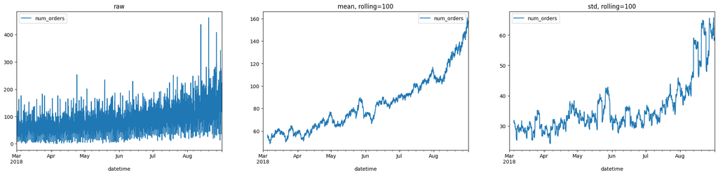

```python
fig, ax = plt.subplots(1, 3, figsize=(25, 5))

df.plot(ax=ax[0])
ax[0].set_title('raw')

df.rolling(100).mean().plot(ax=ax[1])
ax[1].set_title('mean, rolling=100')

df.rolling(100).std().plot(ax=ax[2])
ax[2].set_title('std, rolling=100')

plt.show()
```

Исходя из графиков уже становится виден тренд: количество заказов в течение представленного периода в среднем растет. Можно сделать вывод о том, что к концу лета - началу осени наступает пик, и где-то в течение зимы и к началу весны он спадает.

## Анализ

Далее разложим данные на компоненты и определим сезонность.

### Разложение на компоненты

```python
decomposed_df = seasonal_decompose(df)
```

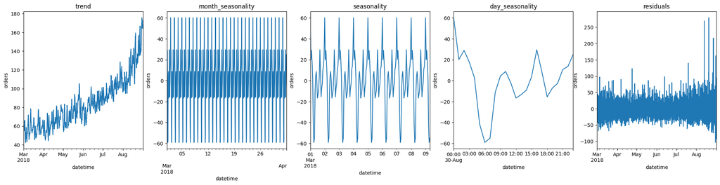

```python
comps = ['trend', 'month_seasonality', 'seasonality', 'day_seasonality', 'residuals']

fig, ax = plt.subplots(1, 5, figsize=(25, 5))

for i, j in zip([decomposed_df.trend, decomposed_df.seasonal['2018-03-01':'2018-04-01'], decomposed_df.seasonal[:200], decomposed_df.seasonal['2018-08-30':'2018-08-30'], decomposed_df.resid], comps):

    i.plot(ax=ax[comps.index(j)])

    ax[comps.index(j)].set_title(j)
    ax[comps.index(j)].set_ylabel('orders')

plt.show()
```

Что видим:

1. Похоже, сезон у нас представлен одним днем (период на графике ограничивается сутками).
2. Тренд, как мы уже заметили, показывает постоянный рост среднего числа заказов в течение всего периода. Судя по графику, тренд растет с ускорением.
3. Остатки в целом равномерны, однако можно увидеть некоторые сильно выбивающиеся значения, т.е. выбросы - форс-мажорные часы и дни. К концу периода их заметно больше, и они скорее всего повлияют на итоговую работу модели.
4. В рамках одного периода больше всего заказов обычно приходится на полночь. Самое меньшее количество заказов наблюдается в 6 утра.

Теперь ресемплируем данные по месяцу, трем дням и двум неделям, чтобы узнать, есть ли у нас другая сезонность, кроме суточной.

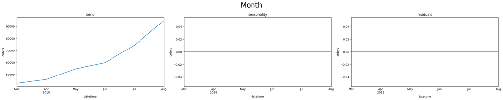

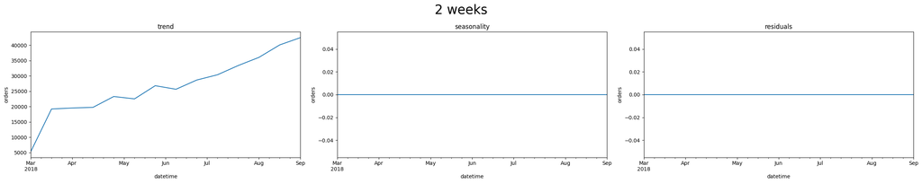

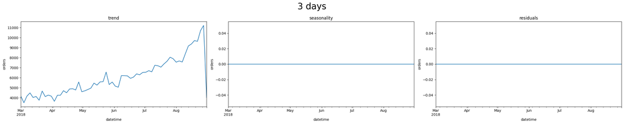

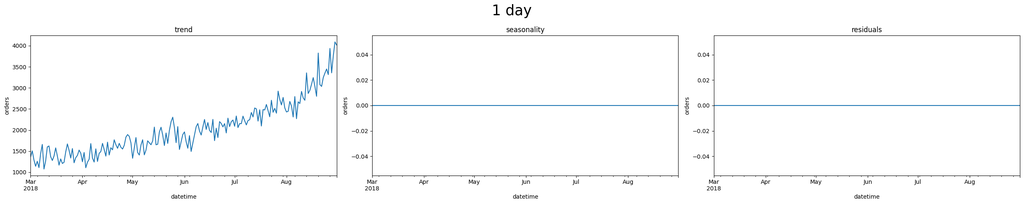

```python
resampled_seasonal_plots()
```

Исходя из графиков можно сделать вывод, что сезонности, кроме суточной, в данных нет. Оценим тренд.

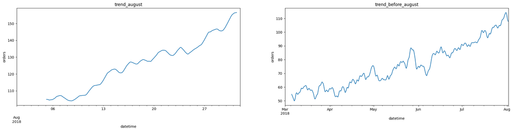

```python
comps = ['trend_august', 'trend_before_august']

fig, ax = plt.subplots(1, 2, figsize=(25, 5))

for i, j in zip([decomposed_df.trend['2018-08-01':'2018-08-31'].rolling(100).mean(), decomposed_df.trend['2018-03-01':'2018-08-01'].rolling(100).mean()], comps):

    i.plot(ax=ax[comps.index(j)])

    ax[comps.index(j)].set_title(j)
    ax[comps.index(j)].set_ylabel('orders')

plt.show()
```

Похоже, мы действительно имеем дело с трендом с ускорением. За все время до августа (5 месяцев) среднее количество заказов увеличилось на +-60, а за один только август это значение поднялось на +-50.

Убедимся в стационарности ряда с помощью статистического теста Дики-Фуллера. Сформулируем гипотезы:

1. H0 - наш временной ряд не стационарен
2. H1 - мы имеем дело со стационарным рядом

```python
stat_result = adfuller(df)

print('p-value = ', stat_result[1])

if stat_result[0] > stat_result[4]['1%']:

    print('(alpha=1%) Похоже, ряд не стационарен')

else:

    print('(alpha=1%) Похоже, ряд стационарен')

if stat_result[0] > stat_result[4]['5%']:

    print('(alpha=5%) Похоже, ряд не стационарен')

else:

    print('(alpha=5%) Похоже, ряд стационарен')
```

```
p-value =  0.028940051402613094
(alpha=1%) Похоже, ряд не стационарен
(alpha=5%) Похоже, ряд стационарен
```

Похоже, мы не можем быть наверняка уверены в том, что имеем дело со стационарным временным рядом, поэтому было бы неплохо перевести наш временной ряд в стационарный.

```python
df_dev = (df - df.shift()).copy().dropna()
display(df_dev.head(3))
```

| datetime | num_orders |
| --- | --- |
| 2018-03-01 01:00:00 | -39.0 |
| 2018-03-01 02:00:00 | -14.0 |
| 2018-03-01 03:00:00 | -5.0 |

Еще раз смотрим на графики компонент.

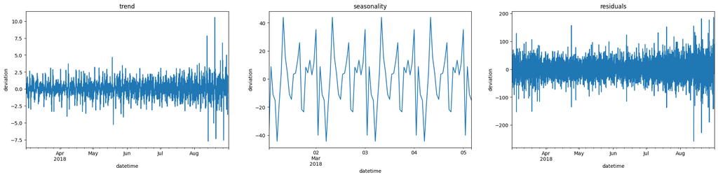

```python
decomposed_df_dev = seasonal_decompose(df_dev)

comps = ['trend', 'seasonality', 'residuals']

fig, ax = plt.subplots(1, 3, figsize=(25, 5))

for i, j in zip([decomposed_df_dev.trend, decomposed_df_dev.seasonal[:100], decomposed_df_dev.resid], comps):

    i.plot(ax=ax[comps.index(j)])

    ax[comps.index(j)].set_title(j)
    ax[comps.index(j)].set_ylabel('deviation')


plt.show()
```

Наш временной ряд переведен, и график тренда показывает плюс-минус одно и то же распределение; там же замечаем ранее обозначенные выбросы ближе к концу периода.

Далее создадим новые признаки, но пока не все. Нам нужно оценить изменение числа заказов в течение всего периода (по месяцам), недели и одного сезона (суток).

```python
data = make_features(df_dev, 1, 3)
```

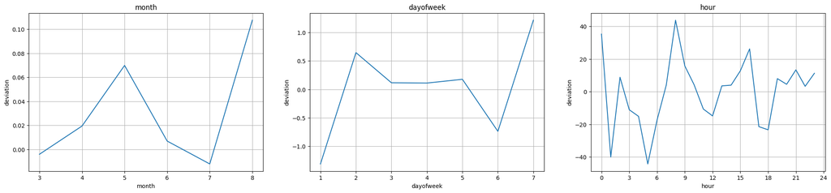

```python
features = ['month', 'dayofweek', 'hour']

fig, ax = plt.subplots(1, 3, figsize=(25, 5))

for i in features:

    if i == 'hour':
        ax[features.index(i)].set_xticks(np.arange(0, 25, 3))

    data.groupby(i)['num_orders'].mean().plot(ax=ax[features.index(i)])

    ax[features.index(i)].set_title(i)
    ax[features.index(i)].set_ylabel('deviation')

    ax[features.index(i)].grid()

plt.show()
```

Что мы наблюдаем:

1. Общее увеличение среднего отклонения к концу периода, которое мы заметили ранее.
2. Похоже, в самом конце недели чаще случаются "незапланированные" вызовы такси, что немудрено: люди частенько выпивают и по этой причине не могут вести машину, вызывая такси.
3. Наш сезон - это сутки. Похоже, чаще и больше всего вызовов обычно поступает в период с 6 до 9 утра, а также в полночь. Низовая активность - в час ночи (сразу за полуночью), в районе 5 часов утра, и в 17-18 часов пополудни, затем начинет плавно расти к полуночи.

Построим базовый предиктор, который будет прогнозировать константу и вычислять RMSE на основе значений предыдущего ряда.

```python
baseline = baseline_predictor(df_dev, 15, 45)
print(baseline)
```

```
['best_metric_value: 49.78', "optimal_features: {'max_lag_count': 1, 'rolling_mean_size': 32}"]
```

Метрика RMSE равна 49.78, мы должны сделать точно не хуже при обучении и тестировании моделей. Первостепенно ориентируемся на RMSE < 48 (по условию задачи).

## Подготовка

Прежде чем приступить, подготовим данные. Снова вызовем функцию создания признаков, и определим их значения так:

1. max_lag = 24. Наш сезон составляет сутки, поэтому будет полезно учитывать +-все предыдущие значения за период. От ненужных мы избавимся после оценки важности признаков.
2. rolling_mean_size = 24. Опять же, учитываем среднее за предыдущий период.

```python
data = make_features(df_dev, 24, 24)
print(data.shape)
```

```
(4391, 30)
```

```python
data = data.rename(columns={'num_orders': 'diff_prev'})
data = data.merge(df['num_orders'], left_index=True, right_index=True)
```

Всё готово, можно приступать к созданию выборок.

```python
train, test = train_test_split(data, test_size=test_size, shuffle=False)
```

```python
X_train = train.drop(['num_orders', 'diff_prev'], axis=1)
X_test = test.drop(['num_orders', 'diff_prev'], axis=1)

y_train = train['diff_prev']
y_test = test['diff_prev']

test_orders_num = test['num_orders']

num_cols = X_train.columns.to_list()

data_preprocessing = ColumnTransformer(

    [
        ('num', StandardScaler(), num_cols)
    ],
    remainder='passthrough'
)
```

Подготовка проведена, можно приступать к обучению моделей. Всего мы обучим 5 моделей: 3 классических (svm, линейную регрессию и дерево решений) и 2 модели градиентного бустинга - LightGBM и Catboost. Сравним их оценки при кросс-валидации и выберем лучшую для тестирования.

## Обучение

### Классические модели

```python
%%time

pipe = Pipeline(
    [
        ('preprocessing', data_preprocessing),
        ('models', LinearRegression())
    ]
)

param_distributions = [
    {
        'models': [LinearRegression()],
        'preprocessing__num': [StandardScaler(),
                               MinMaxScaler(),
                               RobustScaler(),
                               'passthrough'
                              ]
    },

    {
        'models': [DecisionTreeRegressor(random_state=RANDOM_STATE)],
        'models__max_depth': [None] + [i for i in range(1, 7)],
        'models__max_features': np.arange(1, 30),
        'models__min_samples_leaf': np.arange(1, 30),
        'preprocessing__num': ['passthrough']
    },

    {
        'models': [SVR()],
        'models__kernel': ['rbf', 'sigmoid'],
        'models__degree': np.arange(1, 5),
        'models__C': [np.round(i, 2) for i in np.arange(0.1, 5, 0.1)],
        'models__gamma': [np.round(i, 2) for i in np.arange(1, 5, 0.1)],
        'preprocessing__num': [StandardScaler(),
                               MinMaxScaler(),
                               RobustScaler()
                              ]
    },

    {
        'models': [SVR()],
        'models__kernel': ['linear', 'poly'],
        'models__degree': range(1, 5),
        'models__C': [np.round(i, 2) for i in np.arange(0.1, 5, 0.1)],
        'preprocessing__num': [StandardScaler(),
                               MinMaxScaler(),
                               RobustScaler()
                              ]
    }
]

tscv = TimeSeriesSplit(n_splits=3)
rscv = RandomizedSearchCV(pipe,
                          param_distributions=param_distributions,
                          cv=tscv,
                          scoring='neg_root_mean_squared_error',
                          n_iter=35,
                          n_jobs=-1,
                          verbose=1,
                          random_state=RANDOM_STATE
                         )

rscv.fit(X_train, y_train)

print('##########################')
print('CV-RMSE лучшей модели: {}'.format(np.abs(round(rscv.best_score_, 2))))
print('##########################')
```

```
Fitting 3 folds for each of 35 candidates, totalling 105 fits
##########################
CV-RMSE лучшей модели: 28.0
##########################
CPU times: total: 1.44 s
Wall time: 9.47 s
```

### LightGBM

```python
%%time
lgb_pipe = Pipeline(
    [
        ('preprocessing', data_preprocessing),
        ('model', LGBMRegressor(n_jobs=-1, random_state=RANDOM_STATE))
    ]
)

lgb_params = [
    {
        'preprocessing__num': [StandardScaler(),
                               MinMaxScaler(),
                               RobustScaler(),
                               'passthrough'
                              ]
    }
]


tscv = TimeSeriesSplit(n_splits=5)
grid_lgb = GridSearchCV(lgb_pipe,
                        param_grid=lgb_params,
                        cv=tscv,
                        scoring='neg_root_mean_squared_error',
                        n_jobs=-1,
                        verbose=1
                       )



grid_lgb.fit(X_train, y_train)

print('##########################')
print('CV-RMSE лучшей модели: {}'.format(np.abs(round(grid_lgb.best_score_, 2))))
print('##########################')
```

```
Fitting 5 folds for each of 4 candidates, totalling 20 fits
[LightGBM] [Info] Auto-choosing col-wise multi-threading, the overhead of testing was 0.000701 seconds.
You can set `force_col_wise=true` to remove the overhead.
[LightGBM] [Info] Total Bins 4729
[LightGBM] [Info] Number of data points in the train set: 3951, number of used features: 29
[LightGBM] [Info] Start training from score 0.021514
##########################
CV-RMSE лучшей модели: 26.26
##########################
CPU times: total: 1.14 s
Wall time: 1.91 s
```

### Catboost

```python
pd.DataFrame.iteritems = pd.DataFrame.items
```

```python
%%time
cb_pipe = Pipeline(
    [
        ('preprocessing', data_preprocessing),
        ('model', CatBoostRegressor(thread_count=-1, logging_level='Silent', random_state=RANDOM_STATE))
    ]
)

cb_params = [
    {
        'preprocessing__num': [StandardScaler(),
                               MinMaxScaler(),
                               RobustScaler(),
                               'passthrough'
                              ]
    }
]

tscv = TimeSeriesSplit(n_splits=5)
grid_cb = GridSearchCV(cb_pipe,
                       param_grid=cb_params,
                       cv=tscv,
                       scoring='neg_root_mean_squared_error',
                       n_jobs=-1,
                       verbose=1,
                       refit=True
                      )

grid_cb.fit(X_train, y_train)

print('##########################')
print('CV-RMSE лучшей модели: {}'.format(np.abs(round(grid_cb.best_score_, 2))))
print('##########################')
```

```
Fitting 5 folds for each of 4 candidates, totalling 20 fits
##########################
CV-RMSE лучшей модели: 25.6
##########################
CPU times: total: 32.3 s
Wall time: 32.3 s
```

Лучшей моделью получилась модель Catboost, поэтому тестировать будем её.

P.S. Я пробовал подобрать гиперпараметры моделей LGBM и Catboost, но это только делало их хуже (метрика стабильно была хуже на 3-5 пунктов), процесс занял довольно много времени, и я не стал включать ячейки с кодом в итоговую работу, т.к. несколько раз приходилось перезапускать весь код сначала.

## Тестирование

Оценим важность признаков, которые мы передавали лучшей модели для обучения.

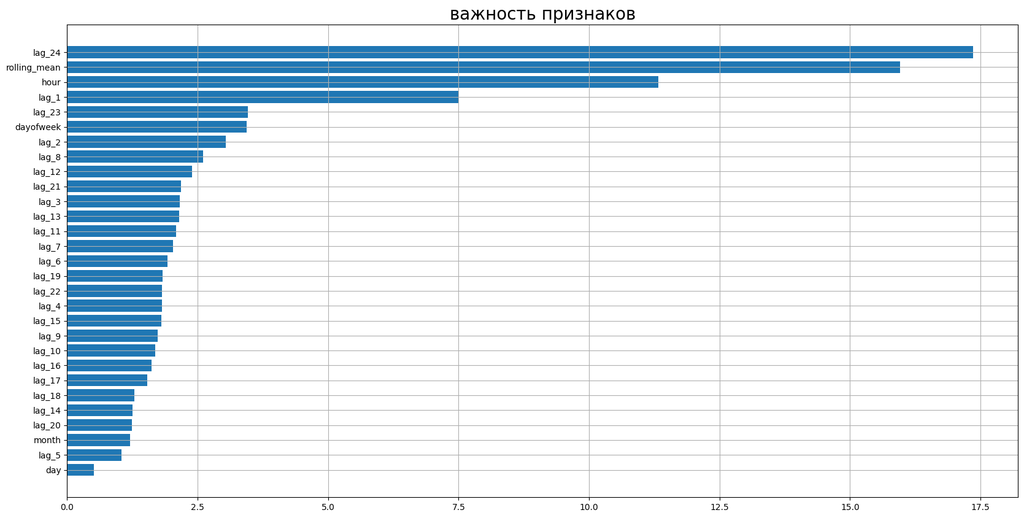

```python
importances = pd.DataFrame(data={'feature': X_train.columns,
                                 'importance': grid_cb.best_estimator_.named_steps.model.feature_importances_
                                }
                          )
importances = importances.sort_values(by='importance', ascending=True)

fig, ax = plt.subplots(1, 1, figsize=(20, 10))

plt.barh(y=importances['feature'], width=importances['importance'])

plt.title('важность признаков', size=20)

plt.grid()

plt.show()
```

Итак, что мы видим:

1. Одними из наиболее важных признаков с большим отрывом оказались скользящее среднее и час заказа, что неудивительно.
2. Определяющим признаком оказался признак lag_24. Также весьма важен признак lag_23. Похоже, мы не зря взяли данные за весь предыдущий цикл.
3. Все остальные признаки оказались более-менее учитываемы моделью, лишних нет.

Теперь получим метрику RMSE на тестовых данных для нашей модели, но сначала переведем полученные предсказания (мы предсказывали изменение таргета) в количество заказов.

```python
y_pred = grid_cb.best_estimator_.predict(X_test)

test_orders = pd.merge(y_test, test_orders_num, left_index=True, right_index=True)
test_predictions_series = pd.Series(y_pred, name='predictions')
test_predictions = pd.concat([test_predictions_series, test_orders_num.reset_index(drop=False)], axis=1).set_index('datetime')

test_predictions['pred_orders'] = test_predictions['predictions'] + test_predictions['num_orders'].shift()
test_predictions = test_predictions.dropna()

print('test RMSE: {}'.format(round(np.sqrt(mse(test_predictions['num_orders'], test_predictions['pred_orders'])), 2)))
```

```
test RMSE: 40.98
```

Тестовая метрика составляет 40.98, порядочно меньше 48 (а также метрики baseline-предиктора) и удовлетворяет условиям заказчика.

Оценим распределение остатков модели.

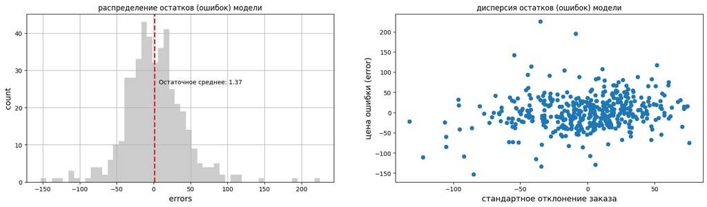

```python
residuals_analysis_plotter(y_test, y_pred, figsize=(20, 5), xlabel='стандартное отклонение заказа', mean_text_x_coef_degree=2.5, mean_text_y_coef=1.9, bins=50, suptitle=None, scatter_grid=False)
```

Графики остатков показывают:

1. Остаточное среднее равно 1.37 и означает, что модель систематически немного занижает прогнозы, однако это значение довольно близко к нулю, что хорошо.
2. На гистограмме и графике рассеяния видны выбросы (сильно отстоящие от остальных значения). Скорее всего, это наши форс-мажорные дни или неучтенные запланированные дни повышенного спроса.
3. Дисперсия ошибок в целом разрежена и постоянна на всем протяжении шкалы прогнозируемых значений. Искажения, опять же, в основном вносят выбросы (наши ранее определенные шумы на графиках компонент).

## Вывод и рекомендации заказчику

**Итоговый вывод:** выбранная модель показала неплохой результат (что также подтверждается графиками остатков), удовлетворяющий условиям, и готова к работе.

Также в дальнейшем можно попробовать улучшить модель: